# Millipede Resolution

```r
get_prior(model.formula,data=df)
```

```
##                  prior class      coef      group resp dpar     nlpar
## 1  student_t(3, 0, 10) sigma
## 2                          b                                     base
## 3                          b Intercept                           base
## 4                          b                                    lapse
## 5                          b Intercept                          lapse
## 6  student_t(3, 0, 10)    sd                                    lapse
## 7                         sd           individual               lapse
## 8                         sd Intercept individual               lapse
## 9                          b                                threshold
## 10                         b Intercept                      threshold
## 11 student_t(3, 0, 10)    sd                                threshold
## 12                        sd           individual           threshold
## 13                        sd Intercept individual           threshold
## 14                         b                                    width
## 15                         b Intercept                          width
## 16 student_t(3, 0, 10)    sd                                    width
## 17                        sd           individual               width
## 18                        sd Intercept individual               width
##    bound
## 1
## 2
## 3
## 4
## 5
## 6
## 7
## 8
## 9
## 10
## 11
## 12
## 13
## 14
## 15
## 16
## 17
## 18
```

```r
model.priors  <- c(
                   prior(normal(0.167, 0.05),     nlpar = "base"                       ,lb = 0,ub=0.35),
                   prior(normal(0.1,0.2),         nlpar = "lapse"                            ,ub = 0.5),
                   prior(normal(1,1),             nlpar= 'threshold',  class = 'b'                     ),
                     prior(normal(1,1),             nlpar = 'width',     class = 'b'                     ),
                   # hyperpriors on the random effects
                   prior(student_t(3,0,0.25),      nlpar = "lapse",     class = sd                    ),
                   prior(student_t(3,0,0.25),      nlpar = "threshold", class = sd                    ),
                   prior(student_t(3,0,0.25),      nlpar = "width",     class = sd                    )
                   )
```

```r
model_fit  <- brm(model.formula, data = df, family = bernoulli("identity"), iter = 5000,
              chains = 4, prior = model.priors, control = list(max_treedepth = 12,adapt_delta=0.99))
model_fit  <- add_criterion(model_fit, c("loo","waic"))
```

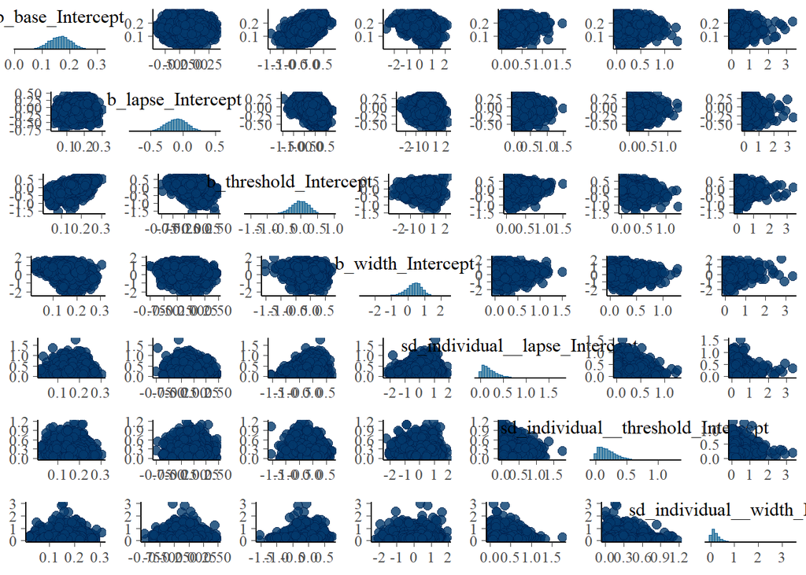

```r
pairs(model_fit)
```

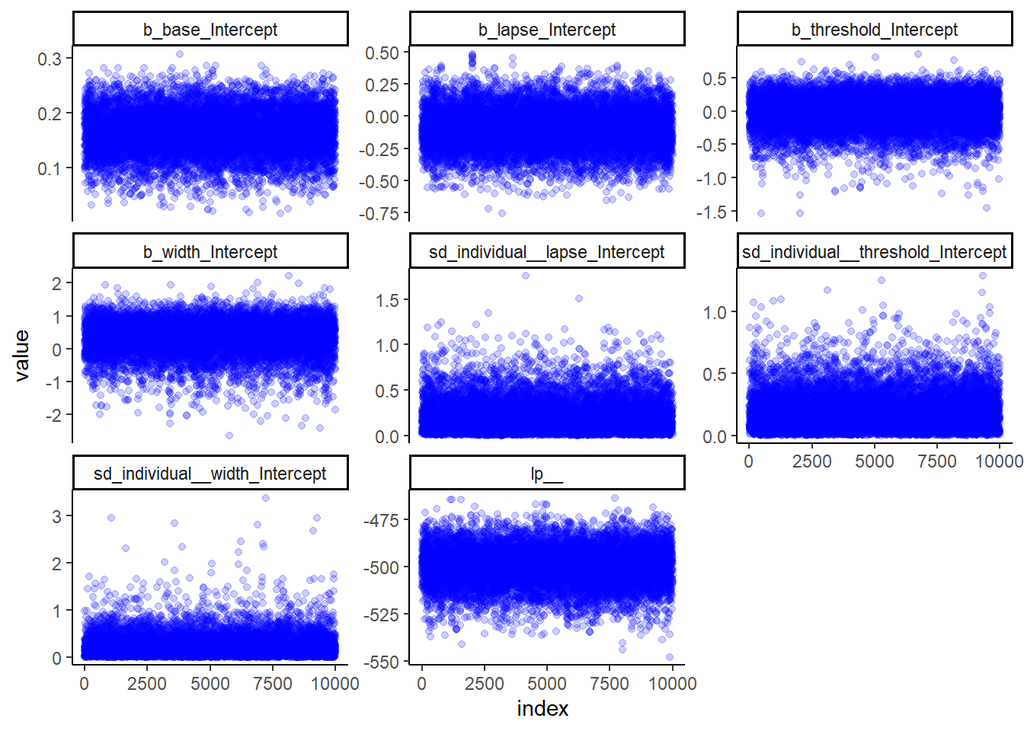

```r
samples <- posterior_samples(model_fit)
smpl <- mutate(as.data.frame(samples), index = 1:length(lp__))
ggplot(melt(
    dplyr::select(smpl,- starts_with("r_")),
    id.var = "index"), aes(x=index, y=value)) + geom_point(alpha = 0.2, colour = "blue") +
    facet_wrap(~variable, scale = "free_y") + theme_classic()
```

```r
post_sum <- posterior_summary(model_fit,
                  pars=c("b_base_Intercept", "b_lapse_Intercept", "b_threshold_Intercept","b_width_Intercept",
                         "sd_individual__lapse_Intercept","sd_individual__threshold_Intercept","sd_individual__width_Intercept"),
                         probs = c(0.025,  0.975), robust = TRUE)
```

Trace and density plots for MCMC samples.

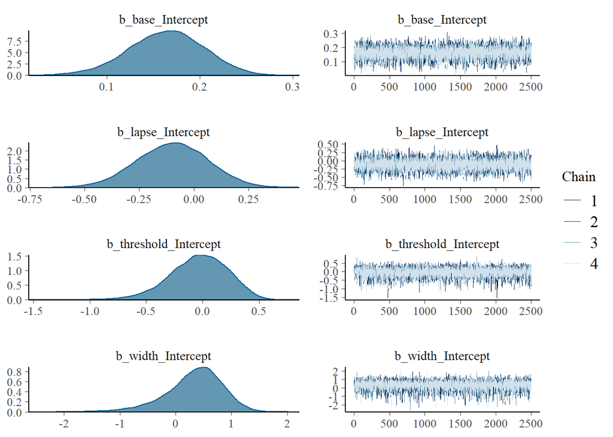

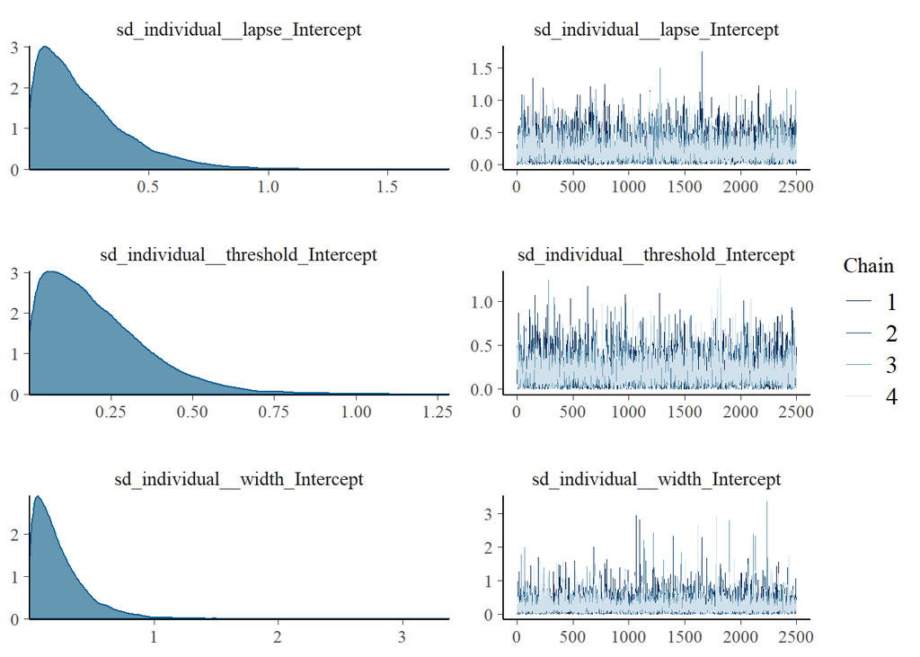

```r
plot(model_fit, ask=F, newpage=F, N=4 )#, N= 7)
```

Plot the threshold and width tranformed into degrees in radians.

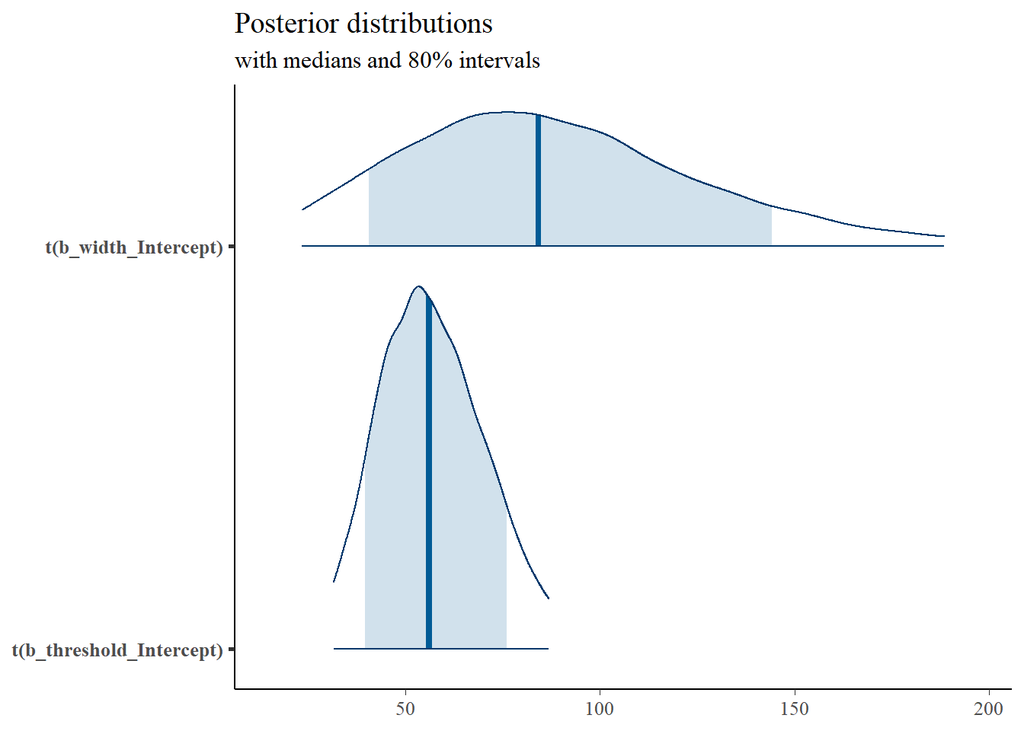

```r
param2deg <- function(x){
  out = 180*exp(x)/pi
  return(out)}
stanplot(model_fit, pars=c("b_width_Intercept","b_threshold_Intercept"), type="areas",
         point_est = "median", prob = 0.8, prob_outer = 0.95,
         transformations = param2deg) +
         ggplot2::labs(title = "Posterior distributions", subtitle = "with medians and 80% intervals")
```

Just the threshold

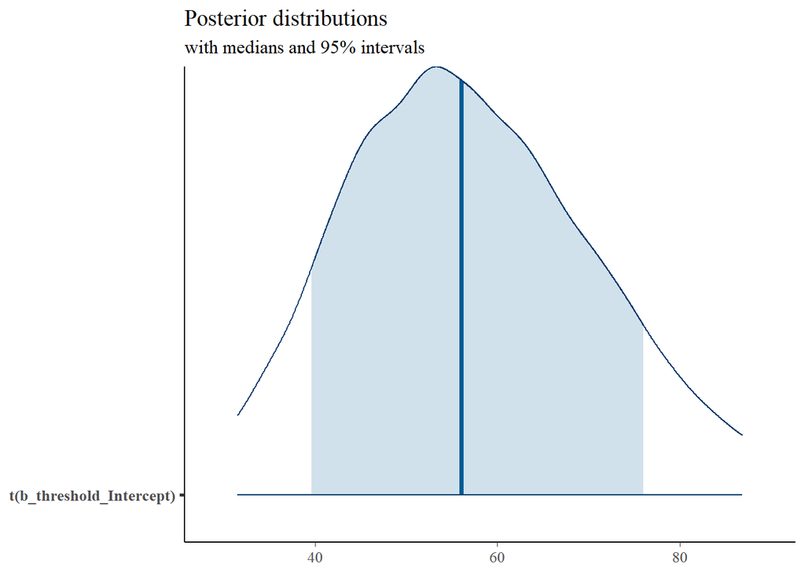

```r
param2deg <- function(x){
  out = 180*exp(x)/pi
  return(out)}
stanplot(model_fit, pars=c("b_threshold_Intercept"), type="areas",
         point_est = "median", prob = 0.8, prob_outer = 0.95,
         transformations = param2deg) +
         ggplot2::labs(title = "Posterior distributions", subtitle = "with medians and 95% intervals")
```

Marginal effects with random effects

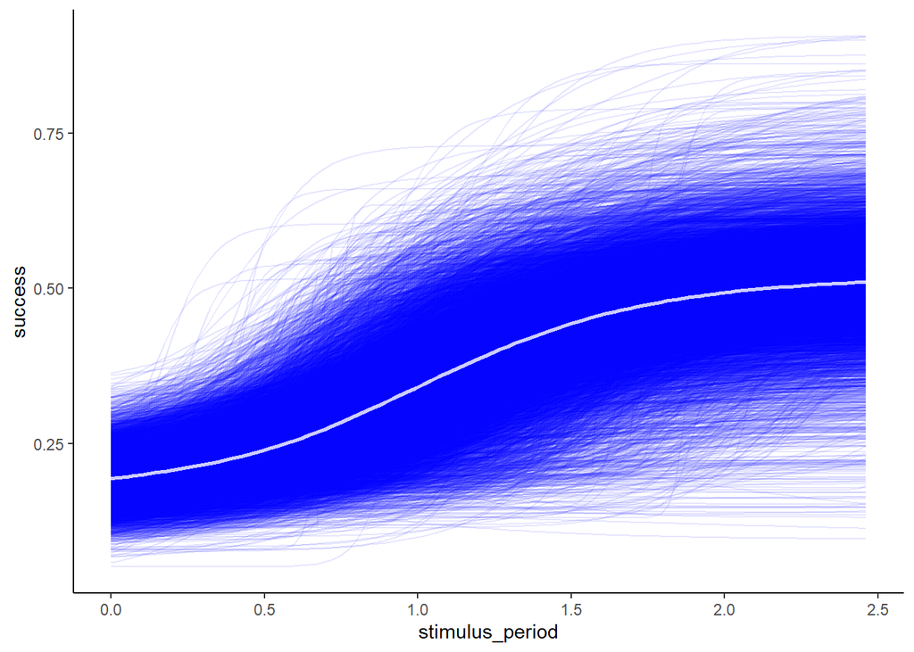

```r
fitted_CI <- marginal_effects(model_fit, method = "fitted", spaghetti = T, robust=T, re_formula = NULL)
plot(fitted_CI, theme=theme_classic(), ask=F)
```

Marginal effects with random effects

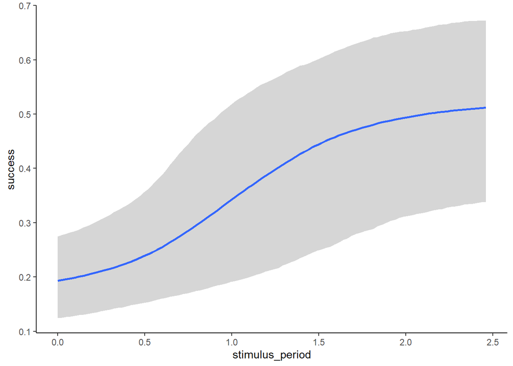

```r
fitted_CI <- marginal_effects(model_fit, method = "fitted", spaghetti = F, robust=T, re_formula = NULL)
plot(fitted_CI, theme=theme_classic(), ask=F)
```

Marginal effects without random effects

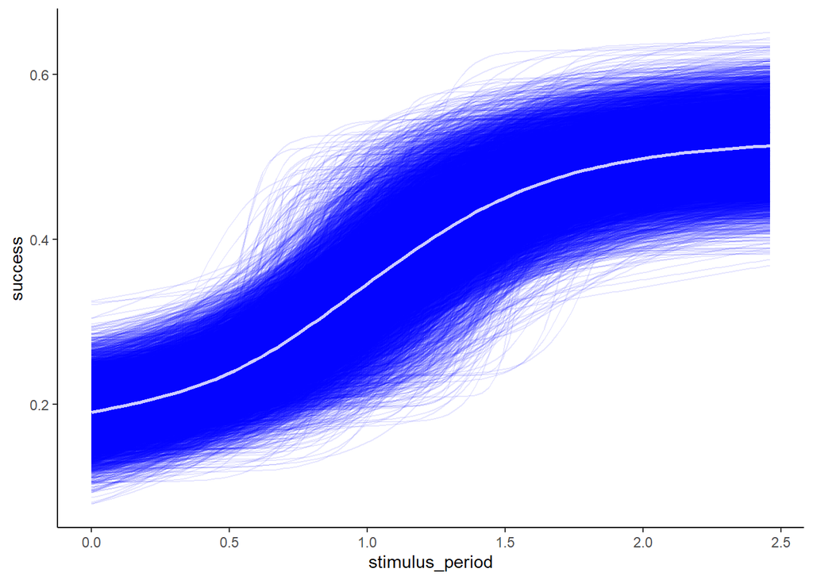

```r
fitted <- marginal_effects(model_fit, method = "fitted", spaghetti = T, probs = c(0.025, 0.975),
                           robust=T, mean=T, re_formula = NA)
plot(fitted, theme=theme_classic(), ask=F)
```

Marginal effects without random effects

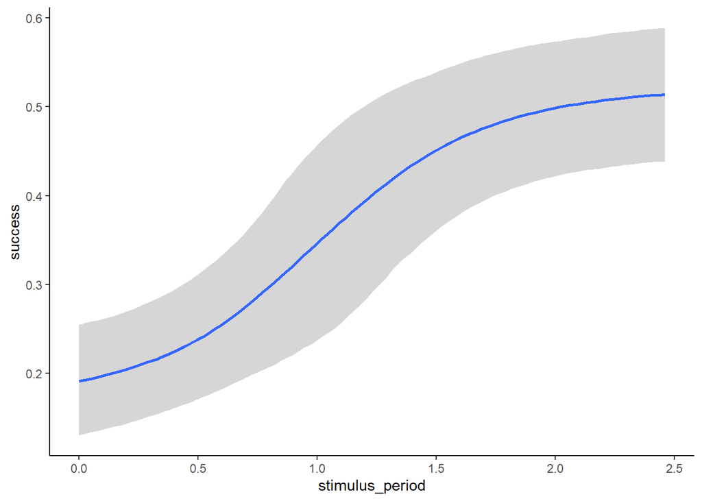

```r
fitted_CI <- marginal_effects(model_fit, method = "fitted", spaghetti = F, robust=T,
                              re_formula = NA)
plot(fitted_CI, theme=theme_classic(), ask=F)
```

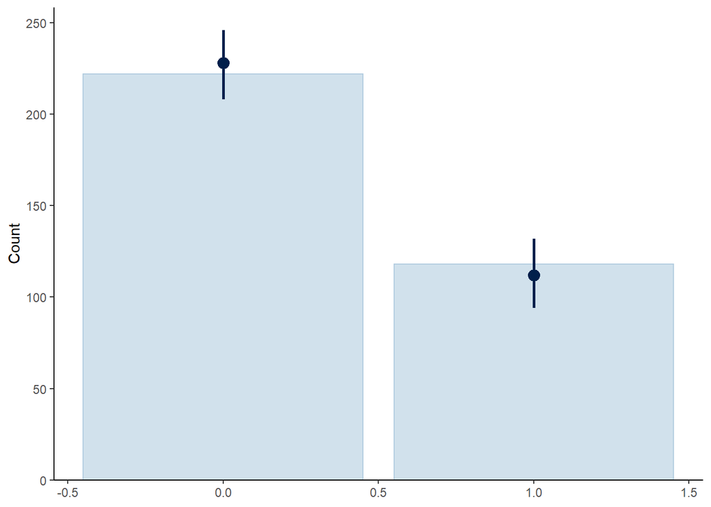

```r
  pp_check(model_fit,nsamples=400, type="bars",) + theme_classic() + theme(legend.position='none')
```

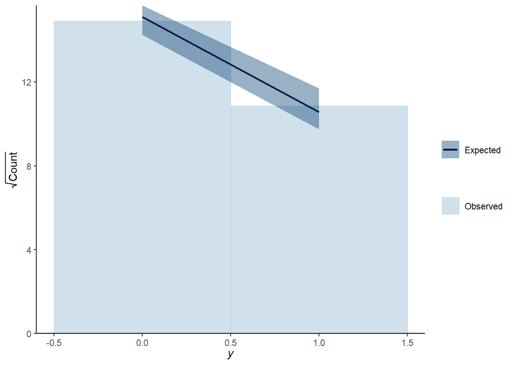

```r
  pp_check(model_fit, type = "rootogram", nsamples = 100, style = "standing", prob=0.9) +   theme_classic()
```

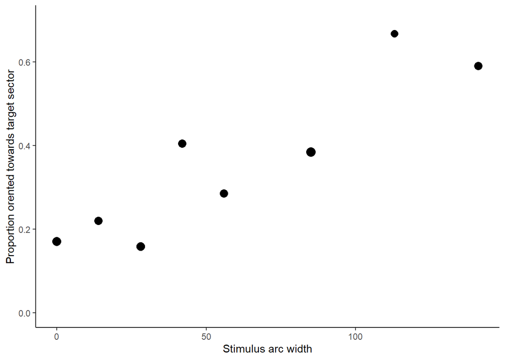

```r
ggplot(data=circ_fun_facts ,aes(x=180*stimulus_period/pi , y=sext.prop, size=n_obs)) +
geom_point() + theme_classic() + scale_size_area(max_size = 4) + theme(legend.position="none") + ylim(0,0.7) +
  ylab("Proportion orented towards target sector") + xlab("Stimulus arc width")
```

```r
null.model.formula <- bf(success ~
                      base +
                      (1 - base - inv_logit(lapse)) *
                      inv_logit(0++4.39*(   1 - exp(threshold)  )   /
                      ( exp (width) ) ),
  base      ~ 1,# + (1|individual), # guess rate has a single value
    lapse     ~ 1 + (1|individual), # lapse rate can be different for different chicks
    threshold ~ 1 + (1|individual), # threshold changes with all effects
    width     ~ 1 + (1|individual), # threshold-width changes with all effects
                      nl = TRUE)

null.model_fit  <- brm(null.model.formula, data = df, family = bernoulli("identity"), iter = 5000,
              chains = 4, prior = model.priors, control = list(adapt_delta=0.9999)) # max_treedepth = 12,
null.model_fit <- add_criterion(null.model_fit, c("loo","waic"))
loo_compare(model_fit,null.model_fit)
```

```
##                elpd_diff se_diff
## model_fit        0.0       0.0
## null.model_fit -15.0       4.5
```

> I did a little check with dummy data and I think the watson.two.test (Watson U^2 test) would be conservative enough for careful comparison of spuriously different distributions.

```r
# watson.two.test()
```

# Extract the Marginal Effects

```r
base.margins <- marginal_effects(model_fit,#model for extraction
                    nlpar = "base", #guess rate
                    method = "fitted",#predicted regression
                    robust = T, #get median estimate ("MED")
                    resolution = 10^3, #fine resolution,smooth
                    points = F, #don't add original data, can't anyway
                    theme=theme_classic(),#default
                    nsamples = 10^3,#resample a lot
                    scale='response',#invert the link function
                    re_formula = NA) # only fixed effects

lapse.margins <- marginal_effects(model_fit,
                    nlpar = "lapse", #lapse rate
                    method = "fitted",#predicted regression
                    robust = T, #get median estimate ("MED")
                    resolution = 10^3, #fine resolution,smooth
                    points = F, #don't add original data, can't anyway
                    theme=theme_classic(),#default
                    nsamples = 10^3,#resample a lot
                    scale='response',#invert the link function
                    re_formula = NA) # only fixed effects
```

Then for threshold and width of the psychometric function in each condition combination - the make_conditions function prepares crossed conditons for each variable - it is necessary to get estimates for both discrete predictor variables.

```r
thresh.margins <- marginal_effects(model_fit,#model for extraction
                    nlpar = "threshold",#threshold
#           conditions=make_conditions(fit,"background"),
                    method = "fitted",#predicted regression
                    robust = T, #get median estimate ("MED")
                    resolution = 10^3, #fine resolution,smooth
                    points = F, #don't add original data, can't anyway
                    theme=theme_classic(),#default
                    nsamples = 10^3,#resample a lot
                    scale='response',#invert the link function
                    re_formula = NA) # only fixed effects

width.margins <- marginal_effects(model_fit,#model for extraction
                    nlpar = "width", #width of threshold
#           conditions=make_conditions(fit,"background"),
                    method = "fitted",#predicted regression
                    robust = T, #get median estimate ("MED")
                    resolution = 10^3, #fine resolution,smooth
                    points = F, #don't add original data, can't anyway
                    theme=theme_classic(),#default
                    nsamples = 10^3,#resample a lot
                    scale='response',#invert the link function
                    re_formula = NA) # only fixed effects
```

# Plot the Marginal Effects

```r
bse <- base.margins$stimulus_period$estimate__[1]
lps <- plogis(lapse.margins$stimulus_period$estimate__[1])
thi <- exp(median(thresh.margins$stimulus_period$estimate__))
wdi <- exp(median(width.margins$stimulus_period$estimate__))
ddCD <- seq(from = 0, to = 6, length.out = 10^3) # #make an x variable to plot against
fofx <- plogis( (4.39 * ((ddCD)-thi))/(wdi) ) # f(x) curve of the psychometric function
phi1 <- bse + (1-lps-bse)*fofx # the psychometric function, accounting for guess rate & lapse rate
```

# Plot the modelled relationships

This section creates variables to plot best fit lines for each set of conditions. The scalar *non-psych* is a fraction that determines the curve’s maximum height above guess rate. Point estimates of the model parameters for each condition are fed into the model for the four treatments.

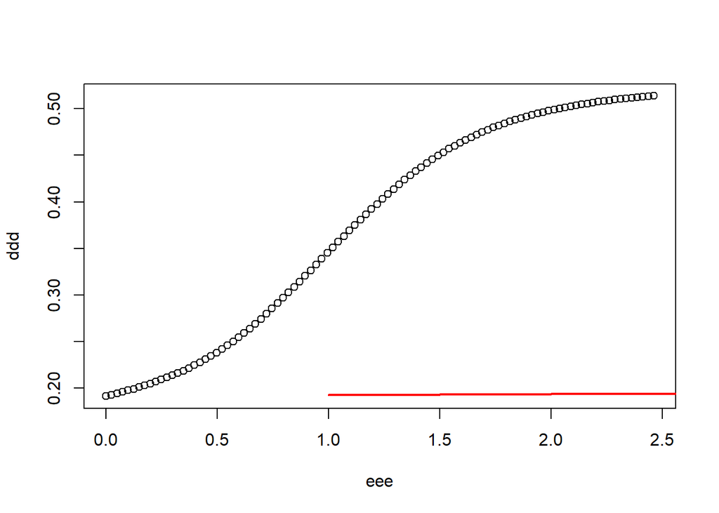

```r
ddd <- as.vector(fitted$stimulus_period$estimate__)
eee <- as.vector(fitted$stimulus_period$stimulus_period)

#### get smoothed curve
lo <- loess(ddd~eee, span=0.5)
plot(eee,ddd)
lines(predict(lo), col='red', lwd=2)
```

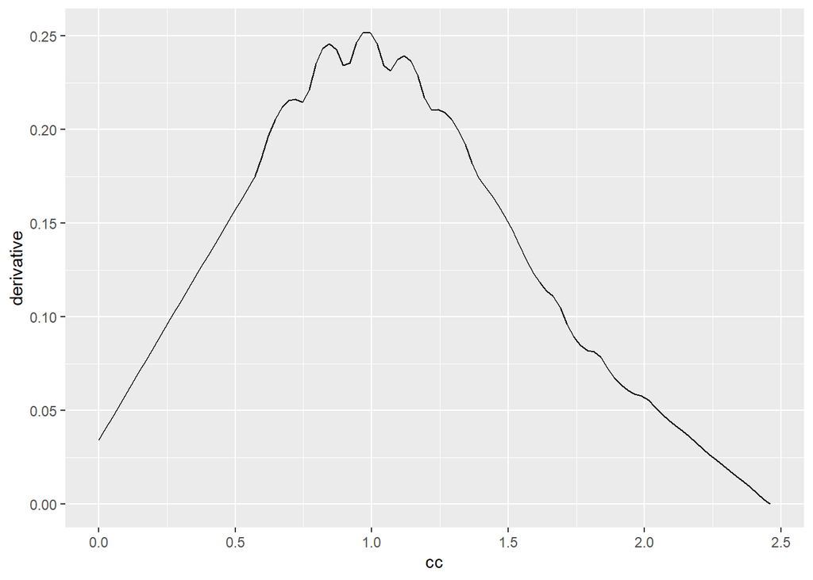

```r
cc <- as.numeric(lo$x); dd <- as.numeric(lo$fitted)
lo.df <- cbind.data.frame(cc,dd)
#data <- lo.df[order(lo.df$x), ]
derivative = c(diff(lo.df$dd) / diff(lo.df$cc), 0)
find.df <- cbind.data.frame(cc,derivative)
ggplot(find.df, aes(cc, derivative)) + geom_line()
```

```r
max_deriv <- which(derivative==max(derivative))
inflection_pt_rads <- cc[max_deriv]
inflection_pt_degs <- inflection_pt_rads*180/pi
inflection_pt_degs
```

```
## [1] 55.54545
```

The CIs in the plot are at 28 + 8.52 degrees = *36.52* degrees and 85 - 2.78 = *82.2* degrees

```r
round(c(36.52,82.2))
```

```
## [1] 37 82
```

```r
signalz <- read_delim('signals.txt', delim="\t")
signalz$target2delrho <- signalz$target2stim*signalz$stim2delrho    ## factor to multiply arc size by to
# to normalize values to the dark fwhm
DoG.crossing.to.fwhm.ratio <- 1/0.614445
```

Rescale the estimate to be comparable to these estimates from Jochen’s MATLAB scripts (described in urchin paper)

```r
detection_estimate         <- c(36.52 ,55.545, 82.2) #c(0.5433509)*(180/pi) #56
detection_estimate         <-  82.2
detection_est_transformed  <- c(detection_estimate) # * sqrt(3) * DoG.crossing.to.fwhm.ratio
#res_ests <- array(dim = c(12,length(detection_estimate)))
#for(i in 1:length(detection_estimate)){
#  res_ests[,i] <- (detection_est_transformed[i] * signalz$stim2delrho[signalz$signal=="DoG"])
#}
res_ests     <- (detection_est_transformed * signalz$stim2delrho[signalz$signal=="DoG"])
res          <- cbind.data.frame(cont_thresh=signalz$contrast.threshold[1:12],res_ests)
```

```r
xx  <- res$cont_thresh
new <- data.frame(cont_thresh = seq(from=min(xx),to=max(xx),length.out=2000))
d <- predict(smooth.spline(res$res_ests ~ res$cont_thresh, df=10), new )
dev.new()
plot(d$x$cont_thresh,d$y$cont_thresh,xlab="Contrast threshold",xlim=c(5,20),ylim = c(30,160),
     ylab="Acceptance angle",bty="n",cex=0.25)
#line(d$x$cont_thresh,d$y$cont_thresh,xlab="Contrast threshold",xlim=c(5,20),ylim = c(30,100),
#     ylab="Acceptance angle",bty="n",cex=0.25)
#ggplot(data= res, aes(x=cont_thresh,y=2:4)) + geom_smooth()
```